# Intro to Rethinking Package

Jim Albert

7/10/2017

#### Introduction

Here is a brief introduction to the `rethinking` package.

```r
library(rethinking)
```

#### Specifying a Bayesian Model

We start with a Bayesian model. Using the familiar `cars` dataset, we fit a simple regresssion model.

$$y_i \sim N(a + b \, \, x_i), i = 1, ..., n$$

$$a \sim N(0, 100), b \sim N(0, 10), \sigma \sim unif(0, 50)$$
We define a Bayesian model by the `alist` function.

```r
cars_formula <- alist(
  dist ~ dnorm(mu,sigma),
  mu <- a + b * speed,
  a ~ dnorm(0, 100),
  b ~ dnorm(0, 10),
  sigma ~ dunif(0, 50)
)
```

#### Approximate Normal Fit to Posterior

To obtain an approximate normal fit to the posterior, use the `map` function.

```r
fit1 <- map(cars_formula, data=cars)
```

The `precis` function computes basic summaries for each parameter:

```r
precis(fit1)
```

```
##         Mean StdDev   5.5% 94.5%
## a     -17.41   6.60 -27.96 -6.85
## b       3.92   0.41   3.27  4.57
## sigma  15.07   1.51  12.66 17.48
```

The `extract.samples` function takes a simulated sample from the (approximate) normal posterior.

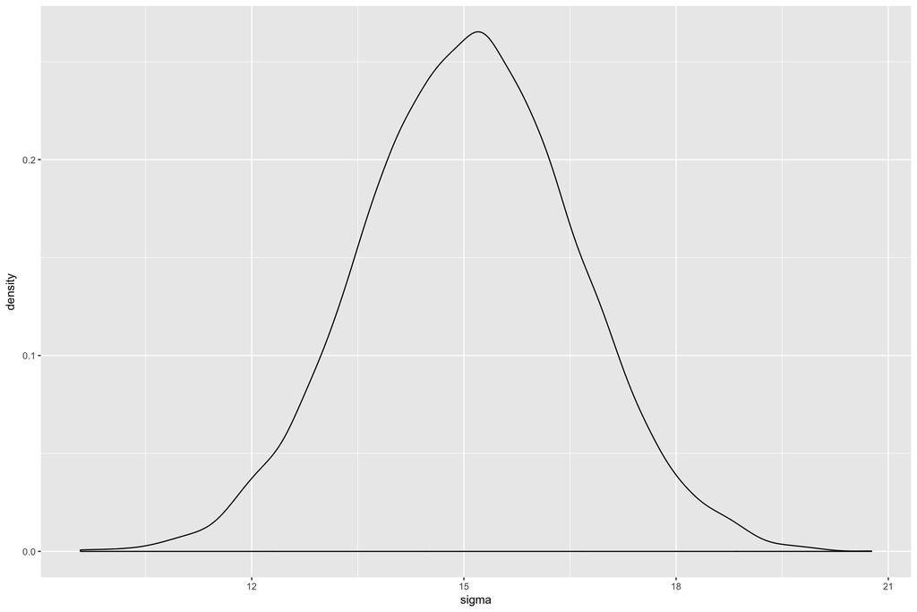

```r
draws <- extract.samples(fit1)
library(ggplot2)
ggplot(draws, aes(sigma)) +
  geom_density()
```

#### Sampling from Exact Posterior

The `map2stan` implements Hamiltonian sampling using the Stan software.

```r
fit2 <- map2stan(cars_formula, data=cars)
```

[output not shown]

[output cut: 35 more lines]

[output not shown]

Again can find summaries and simulated draws by use of the `precis` and `extract.samples` functions.

```r
precis(fit2)
```

```
##         Mean StdDev lower 0.89 upper 0.89 n_eff Rhat
## a     -16.98   7.24     -27.91      -4.64   297 1.01
## b       3.90   0.45       3.20       4.62   285 1.02
## sigma  15.89   1.69      13.13      18.20   562 1.00
```

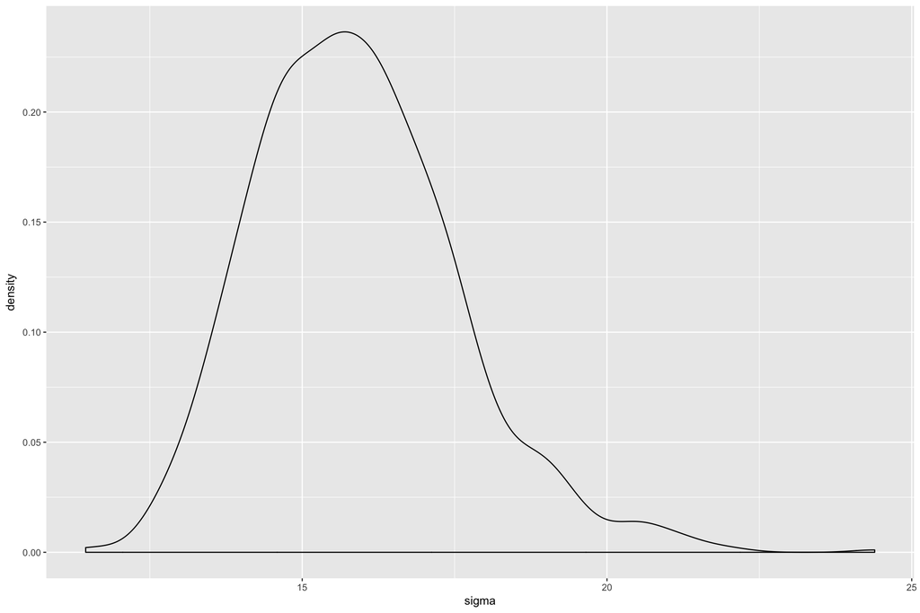

```r
draws2 <- data.frame(extract.samples(fit2))
ggplot(draws2, aes(sigma)) +
  geom_density()
```

The `stancode` function shows you the underlying Stan code that is used to define the Bayesian model.

```r
stancode(fit2)
```

```
## data{
##     int<lower=1> N;
##     real dist[N];
##     real speed[N];
## }
## parameters{
##     real a;
##     real b;
##     real<lower=0,upper=50> sigma;
## }
## model{
##     vector[N] mu;
##     // sigma ~ uniform( 0 , 50 );
##     b ~ normal( 0 , 10 );
##     a ~ normal( 0 , 100 );
##     for ( i in 1:N ) {
##         mu[i] = a + b * speed[i];
##     }
##     dist ~ normal( mu , sigma );
## }
## generated quantities{
##     vector[N] mu;
##     real dev;
##     dev = 0;
##     for ( i in 1:N ) {
##         mu[i] = a + b * speed[i];
##     }
##     dev = dev + (-2)*normal_lpdf( dist | mu , sigma );
## }
```

The `plot` method will show trace plots for the simulated draws for each parameter.

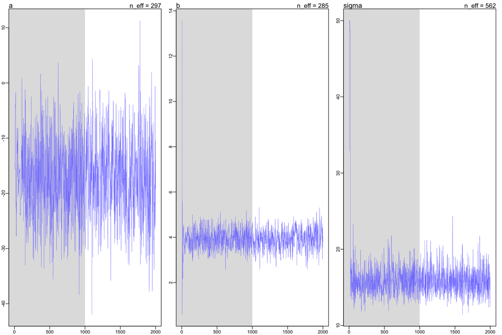

```r
plot(fit2)
```

#### Posterior of Linear Components

Suppose we are interested in learning about the linear component
$$a + b \, \, x$$
for particular values of the covariate x.

I define three values of the speeds of interest.

```r
new_data <- data.frame(speed = c(10, 15, 20))
```

The `link` function simulates values of the linear component for each value of x. The output is a data frame with 1000 rows and 3 columns. I use the `apply` function to find a 80 percent probability interval for each linear component.

```r
sim_parameters <- link(fit2, data=new_data)
```

```
## [ 100 / 1000 ]
[ 200 / 1000 ]
[ 300 / 1000 ]
[ 400 / 1000 ]
[ 500 / 1000 ]
[ 600 / 1000 ]
[ 700 / 1000 ]
[ 800 / 1000 ]
[ 900 / 1000 ]
[ 1000 / 1000 ]
```

```r
apply(sim_parameters, 2, quantile, c(.1, .9))
```

```
##         [,1]     [,2]     [,3]
## 10% 17.86428 38.49959 57.11346
## 90% 26.28109 44.53425 65.17667
```

#### Predictions

Instead suppose we are interested in learning about the future response for selected values of x. The `sim` function simulates from the posterior predictive distribution of future response y. I use `apply` to find 80 percent prediction intervals.

```r
sim_predictions <- sim(fit2, data=new_data)
```

```
## [ 100 / 1000 ]
[ 200 / 1000 ]
[ 300 / 1000 ]
[ 400 / 1000 ]
[ 500 / 1000 ]
[ 600 / 1000 ]
[ 700 / 1000 ]
[ 800 / 1000 ]
[ 900 / 1000 ]
[ 1000 / 1000 ]
```

```r
apply(sim_predictions, 2, quantile, c(.1, .9))
```

```
##          [,1]     [,2]     [,3]
## 10%  2.187249 22.66024 40.38659
## 90% 42.142376 61.09810 80.62289
```